# Big Data Basic Insights

Sudarshan

May 05, 2022

# Motivation

Over the past decade, researchers around the world have generated large amounts of information related to the human gut microbiome. Large scale population studies have cataloged the vast diversity in the human gut microbiome. I wanted to re-visit some of the basic features of the human gut microbiome that are often taken for granted. Such as how many ‘species’ are present in an individual’s gut/fecal sample? Similarly, other questions which I am to visualize in this document. `curatedMetagenomicData` is a useful resource for getting basic insights from wealth of publicly available human metagenomes specifically from the gut.

```r
library(curatedMetagenomicData)
library(tidyverse)
library(scater)
library(ggsci)
library(showtext)
library(ggdist)
library(ggtext)
library(patchwork)
library(gt)
## load fonts
# font_add_google("Poppins", "Poppins")
# font_add_google("Roboto Mono", "Roboto Mono")
showtext_auto()

theme_set(theme_minimal(base_size = 12))

## modify plot elements globally (for all following plots)
theme_update(
  axis.ticks = element_line(color = "grey92"),
  axis.ticks.length = unit(.5, "lines"),
  panel.grid.minor = element_blank(),
  legend.title = element_text(size = 12),
  legend.text = element_text(color = "grey30"),
  plot.title = element_text(size = 18, face = "bold"),
  plot.subtitle = element_text(size = 12, color = "grey30"),
  plot.caption = element_text(size = 9, margin = margin(t = 15))
)
distinct.dark.12 <- c("#19647e", "#CA6702", "#9B2226", "#4b3f72",
                      "#A71969", "#245501", "#0d47a1", "#002962",
                      "#5a189a", "#212529", "#5d2e46", "#603808")
age.cols <- distinct.dark.12[c(1,2,3,5,7)]
names(age.cols) <- c("Newborn", "Child", "Schoolage", "Adult", "Senior")
```

# Extract Data

We follow the simple steps outlined in the `curatedMetagenomicData` to select for samples marked as healthy in the database.  
We extract relative abundance data.

```r
# 2022-05-01
tse <- sampleMetadata |>
  filter(!is.na(age)) |>
  #filter(!is.na(alcohol)) |>
  filter(body_site == "stool") |>
  filter(disease == "healthy") |>
  select(where(~ !all(is.na(.x)))) |>
  returnSamples("relative_abundance", rownames = "short")
tse
saveRDS(tse, "data/curatedMgDTSE.rds")
```

Read stored data.

```r
tse <- readRDS("data/curatedMgDTSE.rds")

table(rowData(tse)$superkingdom)
```

```
##
##   Archaea  Bacteria Eukaryota
##        18      1524        23
```

Some information on the data used here.  
Total number of samples: 9955  
Total number of taxa: 1565  
Total number of participants: 7222  
Total males: 4312  
Total females: 5292  
Total countries: 29  
Age: Min: 0 years; Max: 107 years

Number of participants in age categories:

```r
colData(tse) |>
  as.data.frame() |>
  dplyr::count(age_category) |>
  gt()
```

| age_category | n |
| --- | --- |
| adult | 6042 |
| child | 801 |
| newborn | 2162 |
| schoolage | 229 |
| senior | 721 |

# Data Viz

This is also an attempt at visualizing microbiome data mixing some common visualizations in micorbiome such as barplots and some new visualization from Cédric Scherer. Check out his tutorial [here](https://z3tt.github.io/OutlierConf2021/).

## How many ‘species’ are there in a gut microbiome?

In literature, a variety of numbers are mentioned ranging from 100s to 1000s. So how many do we observe in metagenomics data? We will use the `estimateRichness` function from [`mia` R package](https://www.bioconductor.org/packages/release/bioc/html/mia.html).

```r
tse <- mia::estimateRichness(tse,
                             abund_values = "relative_abundance",
                             index = "observed",
                             name="observed.species")
```

Get data frame from ‘colData’.

```r
tse.df <- as.data.frame(colData(tse))
```

calculate median, max samples.

```r
tse.df <- tse.df |>
  group_by(age_category) %>%
  mutate(
    n = n(),
    median = median(observed.species),
    max = max(observed.species)
  ) %>%
  ungroup()

tse.df <- tse.df |>
  mutate(age_category = str_to_title(age_category))
table(tse.df$age_category)
```

```
##
##     Adult     Child   Newborn Schoolage    Senior
##      6042       801      2162       229       721
```

Plot the observed species in the age categories.

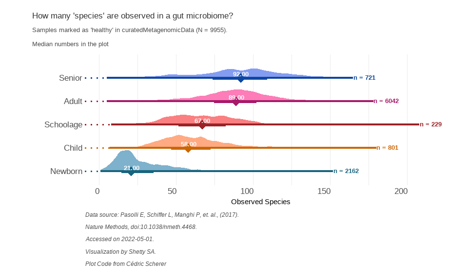

```r
nsamples <- ncol(tse)

tse.df <- tse.df %>%
  mutate(age_category = fct_reorder(age_category, observed.species))

p.main <- ggplot(tse.df, aes(observed.species, age_category, color = age_category,
                             fill = age_category)) +
  theme_minimal() +
  stat_summary(
    geom = "linerange",
    fun.min = function(x) -Inf,
    fun.max = function(x) median(x, na.rm = TRUE),
    linetype = "dotted",
    orientation = "y",
    size = .7
  ) +
  geom_boxplot(
    alpha=0.2,
    width = .15,
    outlier.shape = NA
  ) +
  ggdist::stat_halfeye(
    aes(
      y = age_category,
      color = age_category,
      fill = after_scale(colorspace::lighten(color, .5))
    ),
    shape = 18,
    point_size = 3,
    interval_size = 1.8,
    adjust = .5,
    .width = c(0, 1),
    show.legend = FALSE
  ) +
  geom_text(
    aes(x = median, label = format(round(median, 2), nsmall = 2)),
    stat = "unique",
    color = "white",
    fontface = "bold",
    size = 3.4,
    nudge_y = .15
  ) +
  geom_text(
    aes(x = max, label = glue::glue("n = {n}")),
    stat = "unique",
    fontface = "bold",
    size = 3.5,
    hjust = 0,
    nudge_x = .01,
    nudge_y = .02
  ) +
  coord_cartesian(xlim = c(1.2, NA), clip = "off")+
  scale_color_manual("Age category",values = age.cols) +
  scale_fill_manual("Age category", values = age.cols) +
  labs(title = "How many 'species' are observed in a gut microbiome?" ,
    subtitle = glue::glue("Samples marked as 'healthy' in curatedMetagenomicData (N = {nsamples}).\nMedian numbers in the plot") ,
    y="", x="Observed Species",
    caption = "Data source: Pasolli E, Schiffer L, Manghi P, et. al., (2017).\nNature Methods, doi:10.1038/nmeth.4468.\nAccessed on 2022-05-01.\nVisualization by Shetty SA.\nPlot Code from Cédric Scherer") +
  theme(
    panel.grid.major.x = element_line(size = .35),
    panel.grid.major.y = element_blank(),
    axis.text.y = element_text(size = 13, hjust = 1),
    axis.text.x = element_text(size = 13, hjust = 1),
    axis.ticks.length = unit(0, "lines"),
    plot.title.position = 'plot',
    plot.title = element_text(size = 13, color = "grey20"),
    plot.subtitle = element_text(size = 10, color = "grey30"),
    plot.margin = margin(10, 25, 10, 25),
    legend.position = "none",
    plot.caption = element_text(hjust = 0, face = "italic", color="grey30")
  )
p.main
```

## How many ‘species’ make-up 90% of the community?

While there are several species in the human gut microbiome, there are few that dominate. So how many of the observed species account for 90% of the total community? here, we choose an arbitrary value of 90%. Other possible threshold can also be used.

```r
#colData(tse)
tse <- mia::estimateDiversity(tse,
                              abund_values = "relative_abundance",
                              index = "coverage",
                              name="Coverage")

# tse
tse.df <- as.data.frame(colData(tse))
tse.df <- tse.df |>
  group_by(age_category) %>%
  mutate(perc_cov= (Coverage/observed.species)*100) |>
  mutate(
    n.cov = n(),
    median.cov = median(Coverage),
    max.cov = max(Coverage)
  ) %>%
  ungroup()

tse.df <- tse.df |>
  mutate(age_category = str_to_title(age_category))
```

Plot coverage

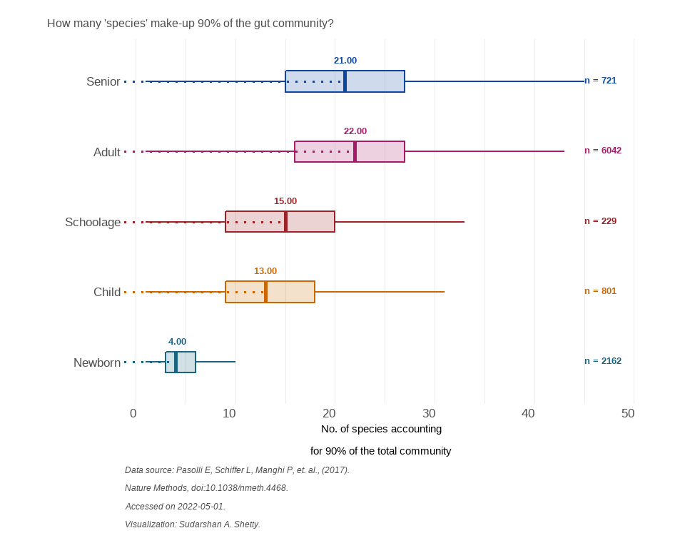

```r
tse.df <- tse.df %>%
  mutate(age_category2 = factor(as.character(age_category), levels = rev(c("Senior", "Adult",
                                                                           "Schoolage", "Child",
                                                                           "Newborn"))))

p.cov <- ggplot(tse.df, aes(Coverage, age_category2, color = age_category2,
                            fill = age_category2)) +
  theme_minimal() +
  stat_summary(
    geom = "linerange",
    fun.min = function(x) -Inf,
    fun.max = function(x) median(x, na.rm = TRUE),
    linetype = "dotted",
    orientation = "y",
    size = .7
  ) +
  geom_boxplot(
    alpha=0.2,
    width = .3,
    outlier.shape = NA) +
  geom_text(
    aes(x = median.cov, label = format(round(median.cov, 2), nsmall = 2)),
    stat = "unique",
    #color = "grey70",
    fontface = "bold",
    size = 3.4,
    nudge_y = .3
  ) +
  geom_text(
    aes(x = 45, label = glue::glue("n = {n.cov}")),
    stat = "unique",
    fontface = "bold",
    size = 3.5,
    hjust = 0,
    nudge_x = .01,
    nudge_y = .02
  ) +
  coord_cartesian(xlim = c(1.2, NA), clip = "off")+
  scale_color_manual("Age category",values = age.cols) +
  scale_fill_manual("Age category", values = age.cols) +
  labs(#title = "" ,
    subtitle = "How many 'species' make-up 90% of the gut community?",
    y="", x=glue::glue("No. of species accounting\nfor 90% of the total community"),
    caption = "Data source: Pasolli E, Schiffer L, Manghi P, et. al., (2017).\nNature Methods, doi:10.1038/nmeth.4468.\nAccessed on 2022-05-01.\nVisualization: Sudarshan A. Shetty.") +
  theme(
    panel.grid.major.x = element_line(size = .35),
    panel.grid.major.y = element_blank(),
    axis.text.y = element_text(size = 13, hjust = 1),
    axis.text.x = element_text(size = 13, hjust = 1),
    axis.ticks.length = unit(0, "lines"),
    plot.title.position = 'plot',
    plot.subtitle = element_text(size = 12, color = "grey30"),
    plot.margin = margin(10, 25, 10, 25),
    legend.position = "none",
    plot.caption = element_text(hjust = 0, face = "italic", color="grey30")
  )
p.cov
```

## What are the most diverse phyla?

The most common phylum in the human gut are Firmicutes, Proteobacteria, Actinobacteria, Bacteroidetes, Fusobacteria. So which of these has the highest representation?

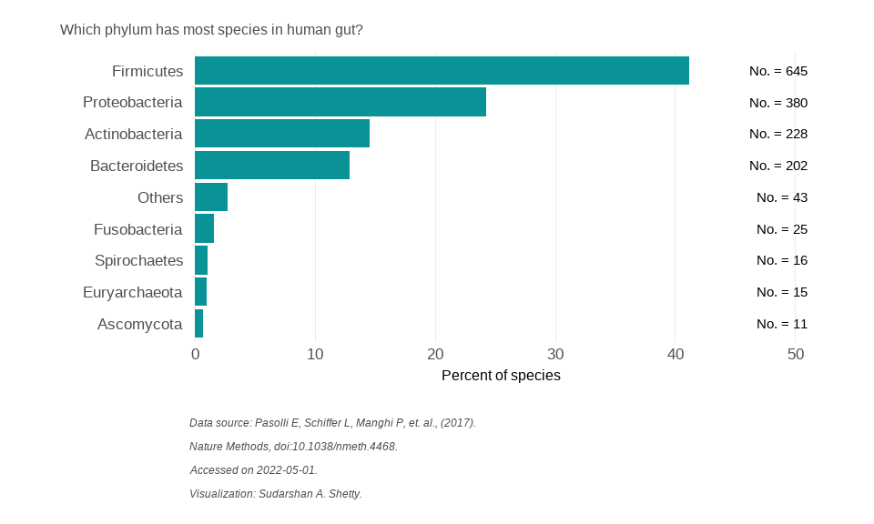

```r
phy.df <- rowData(tse) |>
  as.data.frame() |>
  count(phylum) |>
  arrange(desc(n)) |>
  mutate(Phylum=ifelse(n >10, phylum, "Others")) |>
  group_by(Phylum) |>
  summarise(n=sum(n)) |>
  mutate(species=paste0("n = ", "")) |>
  mutate(perc = (n/sum(n))*100)


p.phy <- phy.df |>
  ggplot(aes(perc, reorder(Phylum, perc)))+
  geom_col(fill="#0a9396") +
  geom_text(
    aes(label = glue::glue("No. = {n}"), x=50),
    ## make labels left-aligned
    hjust = 1, nudge_x = 1
  )+
  ## make sure labels doesn't get cut, part 1
  coord_cartesian(clip = "off") +
  scale_x_continuous(expand = c(.01, .01)) +
  scale_fill_identity(guide = "none") +
  theme(
    panel.grid.major.x = element_line(size = .35),
    panel.grid.major.y = element_blank(),
    axis.text.y = element_text(size = 13, hjust = 1),
    axis.text.x = element_text(size = 13),
    axis.ticks.length = unit(0, "lines"),
    plot.title.position = 'plot',
    plot.subtitle = element_text(size = 12, color = "grey30"),
    plot.margin = margin(10, 25, 10, 25),
    legend.position = "none",
    plot.caption = element_text(hjust = 0, face = "italic", color="grey30")) +
  labs(subtitle = "Which phylum has most species in human gut?" ,
    #subtitle = glue::glue("Samples marked as 'healthy' in curatedMetagenomicData (N = {nsamples}).\nMedian numbers in the plot") ,
    y="", x="Percent of species",
    caption = "Data source: Pasolli E, Schiffer L, Manghi P, et. al., (2017).\nNature Methods, doi:10.1038/nmeth.4468.\nAccessed on 2022-05-01.\nVisualization: Sudarshan A. Shetty.")

p.phy
```

## Which genera are dominant in different age groups?

While there are several genera in the human gut and we saw above that few account for 90% of the total community. It is interesting to check which genera are commonly dominate samples from different age categories. Like, Bifidobacteria are known to dominate in new borns compared to adults.

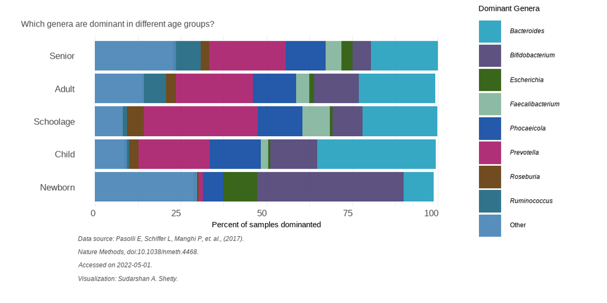

```r
dominant_taxa <- mia::countDominantTaxa(tse,
                                        rank = "genus",
                                        group = "age_category",
                                        abund_values = "relative_abundance",
                                        na.rm = TRUE)

tax.plot <- dominant_taxa |>
  group_by(dominant_taxa) |>
  summarise(sum=sum(rel.freq)) |>
  arrange(desc(sum)) |>
  filter(sum >10) |>
  pull(dominant_taxa)

p.dom <- dominant_taxa |>
  mutate(dominant_taxa2 = ifelse(dominant_taxa %in% tax.plot, dominant_taxa, "Other")) |>
  mutate(dominant_taxa3 = ifelse(dominant_taxa %in% tax.plot, paste0("*",dominant_taxa,"*"), "Other")) |>
  mutate(age_category = str_to_title(age_category),
         age_category2 = factor(age_category, levels = c("Newborn","Child", "Schoolage","Adult","Senior"))) |>
  ## overwrite old percentage labels
  ggplot(aes(y = age_category2, x = rel.freq, fill = dominant_taxa3)) +
  theme_minimal() +
  geom_col(alpha=0.9)+
  ## make sure labels doesn't get cut, part 1
  coord_cartesian(clip = "off") +
  labs(subtitle = "Which genera are dominant in different age groups?" ,
    #subtitle = glue::glue("Samples marked as 'healthy' in curatedMetagenomicData (N = {nsamples}).\nMedian numbers in the plot") ,
    y="", x="Percent of samples dominanted",
    caption = "Data source: Pasolli E, Schiffer L, Manghi P, et. al., (2017).\nNature Methods, doi:10.1038/nmeth.4468.\nAccessed on 2022-05-01.\nVisualization: Sudarshan A. Shetty.") +
  theme(
    legend.text = element_markdown(),
    axis.text.y = element_text(size = 13, hjust = 1),
    axis.text.x = element_text(size = 13, hjust = 1),
    ## make sure labels doesn't get cut, part 2
    plot.margin = margin(15, 30, 15, 15),
    panel.grid.major.x = element_line(size = .35),
    panel.grid.major.y = element_blank(),
    #axis.text.y = element_text(size = 13),
    axis.ticks.length = unit(0, "lines"),
    plot.title.position = 'plot',
    plot.subtitle = element_text(size = 12, color = "grey30"),
    #legend.position = "none",
    plot.caption = element_text(hjust = 0, face = "italic", color="grey30")
  ) +
  scale_fill_manual("Dominant Genera", values = c("#219ebc", "#4b3f72", "#245501",
                                                  "#81b29a", "#0d47a1", "#A71969",
                                                  "#603808","#19647e", "steelblue"))
#
p.dom
```

```r
# p.main
# p.main + p.phy + plot_layout(widths = c(2,1), heights = c(2,0.5)) +
#   plot_annotation(title = "Big Data, Basic Insights")
```

## How does number of observed species vary across age?

Another widely accepted fact is that, number of species tend to increase as we grow older and at adult stage it more or less stabilizes. Here, we have majority cross-sectional samples with few repeated samples. For the sake of simplicity, we plot all samples from different ages.

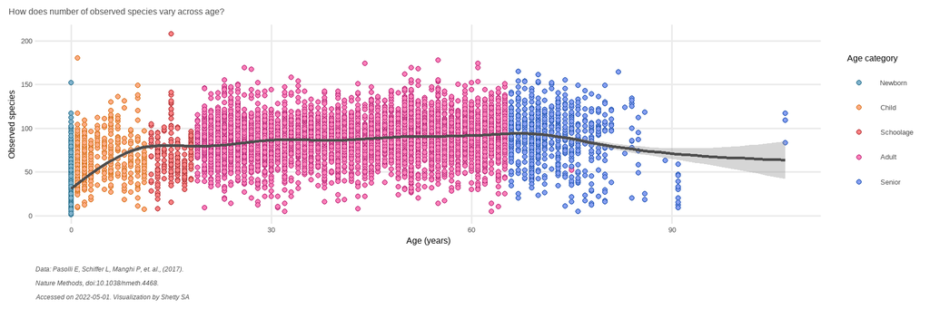

```r
#, alpha=0.5
p.age <- tse.df |>
  ggplot(aes(age,observed.species))+
  geom_point(aes(color=age_category,
                 fill = after_scale(colorspace::lighten(color, .5))),
             shape=21) +
  scale_color_manual("Age category",values = age.cols) +
  scale_fill_manual("Age category",values = age.cols) +
  geom_smooth(colour="grey30") +
  #theme(plot.subtitle = element_text(size = 12, color = "grey30"))+
  labs(x="Age (years)", y="Observed species",
       subtitle = "How does number of observed species vary across age?" ,
       #subtitle = "Median values shown in plot",
       caption = "Data: Pasolli E, Schiffer L, Manghi P, et. al., (2017).\nNature Methods, doi:10.1038/nmeth.4468.\nAccessed on 2022-05-01. Visualization by Shetty SA")+
  theme(
    axis.ticks.length = unit(0, "lines"),
    plot.title.position = 'plot',
    plot.subtitle = element_text(size = 12, color = "grey30"),
    #legend.position = "none",
    plot.caption = element_text(hjust = 0, face = "italic", color="grey30")
  )

p.age
```

```r
((p.main + p.dom)/ (p.age) + plot_layout(widths = c(2,1)))
ggsave("overview01.pdf", h=9, w=14)
ggsave("overview01.png", dpi=180)
```

## How does phylum composition vary across age?

There are differences in composition between age groups. Here, we visualize compositions across age use the commonly used barplots.

```r
tse.phy <- mia::agglomerateByRank(tse, "phylum")
unique(rownames(rowData(tse.phy)))
```

```
##  [1] "Proteobacteria"              "Actinobacteria"
##  [3] "Firmicutes"                  "Fusobacteria"
##  [5] "Bacteroidetes"               "Verrucomicrobia"
##  [7] "Euryarchaeota"               "NA"
##  [9] "Lentisphaerae"               "Synergistetes"
## [11] "Candidatus Thermoplasmatota" "Candidatus Melainabacteria"
## [13] "Tenericutes"                 "Spirochaetes"
## [15] "Ascomycota"                  "Evosea"
## [17] "Cyanobacteria"               "Chloroflexi"
## [19] "Chlamydiae"                  "Basidiomycota"
## [21] "Planctomycetes"              "Deinococcus-Thermus"
## [23] "Euglenozoa"                  "Apicomplexa"
```

```r
ps.phy <- mia::makePhyloseqFromTreeSummarizedExperiment(tse, abund_values="relative_abundance")
```

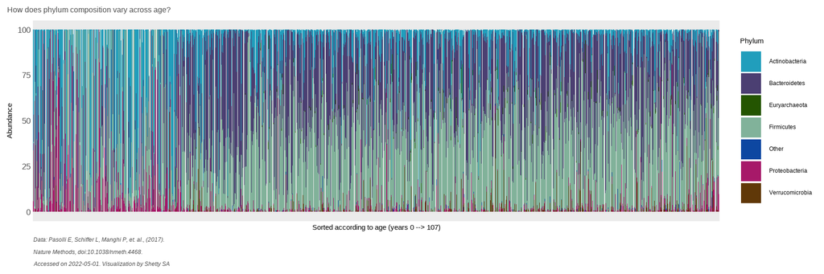

```r
ps.phy.r <- microbiome::aggregate_rare(ps.phy, 0.01, 0.1, level =  "phylum")


p.comp <- microbiome::plot_composition(ps.phy.r, sample.sort = "age",
                                       x.label = "age_category")+
  scale_fill_manual("Phylum", values = c("#219ebc", "#4b3f72", "#245501",
                                         "#81b29a", "#0d47a1", "#A71969",
                                         "#603808","#19647e", "steelblue")) +
  labs(x="Sorted according to age (years 0 --> 107)",
       subtitle = "How does phylum composition vary across age?" ,
       #subtitle = "Median values shown in plot",
       caption = "Data: Pasolli E, Schiffer L, Manghi P, et. al., (2017).\nNature Methods, doi:10.1038/nmeth.4468.\nAccessed on 2022-05-01. Visualization by Shetty SA") +
  theme_minimal() +
  theme(
    legend.text = element_markdown(),
    axis.text.y = element_text(size = 13, hjust = 1),
    axis.text.x = element_blank(),
    ## make sure labels doesn't get cut, part 2
    #plot.margin = margin(15, 30, 15, 15),
    panel.grid.major.x = element_line(size = .35),
    panel.grid.major.y = element_blank(),
    #axis.text.y = element_text(size = 13),
    axis.ticks.length = unit(0, "lines"),
    plot.title.position = 'plot',
    plot.subtitle = element_text(size = 12, color = "grey30"),
    #legend.position = "none",
    plot.caption = element_text(hjust = 0, face = "italic", color="grey30")
  )
p.comp
```

# Combine all plots

We can combine all these plots to create a poster like figure.

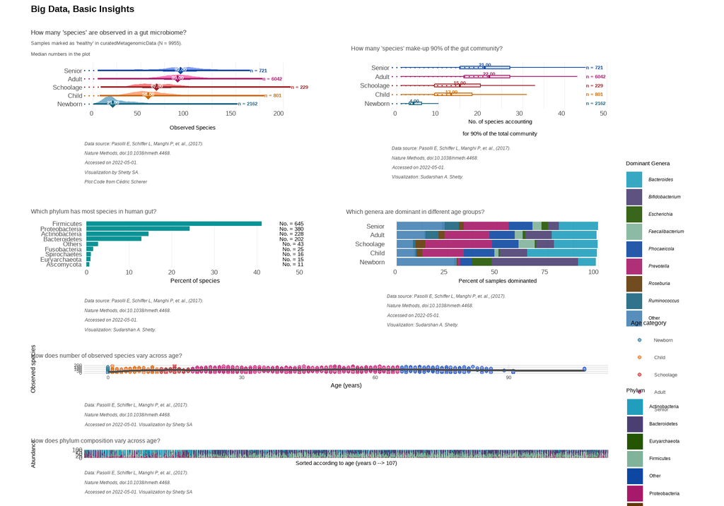

```r
(p.main + p.cov) / (p.phy + p.dom) / (p.age/p.comp) +
  plot_layout(widths = c(1,1,2), heights = c(1,1,2)) +
  plot_annotation(title = "Big Data, Basic Insights")
```

```r
ggsave("overview03.pdf", h=12, w=14)
```

If you have questions or suggestions feel free to contact me:  
sudarshanshetty9[@]gmail[dot]com